# Report on analysis and insight from the data wrangling project

### Brief introduction

In the course of learning data analyst. it has become neccesary to test my data wrangling knowledge which is one of the most difficult stage in data analyst course due to getting, cleaning and tiding of dirty and unkept data. In this project we are to investigate the rating of dogs by Twitter user, why did Twitter users rated some particular breeds of dog compared to others. Data from Twitter was used in the project and the dataset used is listed bellow, however some columns will be renamed in the process of cleaning the data likewise some will be deleted

# Importing liberaries

```python
import pandas as pd
import numpy as np
import os
import requests
import json
import glob
import seaborn as snb
%matplotlib inline
from matplotlib import pyplot as plt
from autoviz.AutoViz_Class import AutoViz_Class
Av = AutoViz_Class()
```

# Load the Merged dataframe

```python
#load the saved file
df_saved_merged = pd.read_csv('df_master_table.csv', sep =',')
```

```python
#check out the merged file
df_saved_merged.head(3)
```

|  | tweet_id | tweet | rating_numerator | rating_denominator | name | dog_phase | Year | Month | WeekDay | retweet_count | ... | jpg_url | first_prediction | first_confidence | first_dog | second_prediction | second_confidence | second_dog | third_prediction | third_confidence | third_dog |
| --- | --- | --- | --- | --- | --- | --- | --- | --- | --- | --- | --- | --- | --- | --- | --- | --- | --- | --- | --- | --- | --- |
| 0 | 666020888022790149 | Here we have a Japanese Irish Setter. Lost eye... | 8.0 | 10.0 | None | NaN | 2015 | 11 | Sunday | 532 | ... | https://pbs.twimg.com/media/CT4udn0WwAA0aMy.jpg | Welsh_springer_spaniel | 0.465074 | True | Collie | 0.156665 | True | Shetland_sheepdog | 0.061428 | True |
| 1 | 666029285002620928 | This is a western brown Mitsubishi terrier. Up... | 7.0 | 10.0 | NaN | NaN | 2015 | 11 | Sunday | 48 | ... | https://pbs.twimg.com/media/CT42GRgUYAA5iDo.jpg | Redbone | 0.506826 | True | Miniature_pinscher | 0.074192 | True | Rhodesian_ridgeback | 0.072010 | True |
| 2 | 666033412701032449 | Here is a very happy pup. Big fan of well-main... | 9.0 | 10.0 | NaN | NaN | 2015 | 11 | Sunday | 47 | ... | https://pbs.twimg.com/media/CT4521TWwAEvMyu.jpg | German_shepherd | 0.596461 | True | Malinois | 0.138584 | True | Bloodhound | 0.116197 | True |

3 rows × 22 columns

# Lets go into the insight

```python
#lets find out how the dataset was distributed
df_saved_merged.describe()
```

|  | tweet_id | rating_numerator | rating_denominator | Year | Month | retweet_count | favorite_count | first_confidence | second_confidence | third_confidence |
| --- | --- | --- | --- | --- | --- | --- | --- | --- | --- | --- |
| count | 1.971000e+03 | 1971.000000 | 1971.0 | 1971.000000 | 1971.000000 | 1971.000000 | 1971.000000 | 1971.000000 | 1.971000e+03 | 1.971000e+03 |
| mean | 7.360418e+17 | 10.500863 | 10.0 | 2015.847286 | 7.165906 | 2784.449518 | 8949.106545 | 0.594558 | 1.345850e-01 | 6.016556e-02 |
| std | 6.752810e+16 | 2.243487 | 0.0 | 0.699178 | 4.117485 | 4697.662893 | 12267.799790 | 0.272126 | 1.010527e-01 | 5.094156e-02 |
| min | 6.660209e+17 | 0.000000 | 10.0 | 2015.000000 | 1.000000 | 16.000000 | 81.000000 | 0.044333 | 1.011300e-08 | 1.740170e-10 |
| 25% | 6.758656e+17 | 10.000000 | 10.0 | 2015.000000 | 3.000000 | 628.500000 | 1997.000000 | 0.363091 | 5.339800e-02 | 1.608055e-02 |
| 50% | 7.088343e+17 | 11.000000 | 10.0 | 2016.000000 | 7.000000 | 1367.000000 | 4147.000000 | 0.587764 | 1.173970e-01 | 4.944380e-02 |
| 75% | 7.880951e+17 | 12.000000 | 10.0 | 2016.000000 | 11.000000 | 3239.000000 | 11402.500000 | 0.847827 | 1.955655e-01 | 9.153815e-02 |
| max | 8.924206e+17 | 17.760000 | 10.0 | 2017.000000 | 12.000000 | 79515.000000 | 132810.000000 | 1.000000 | 4.880140e-01 | 2.734190e-01 |

#### check the dog with highest breed

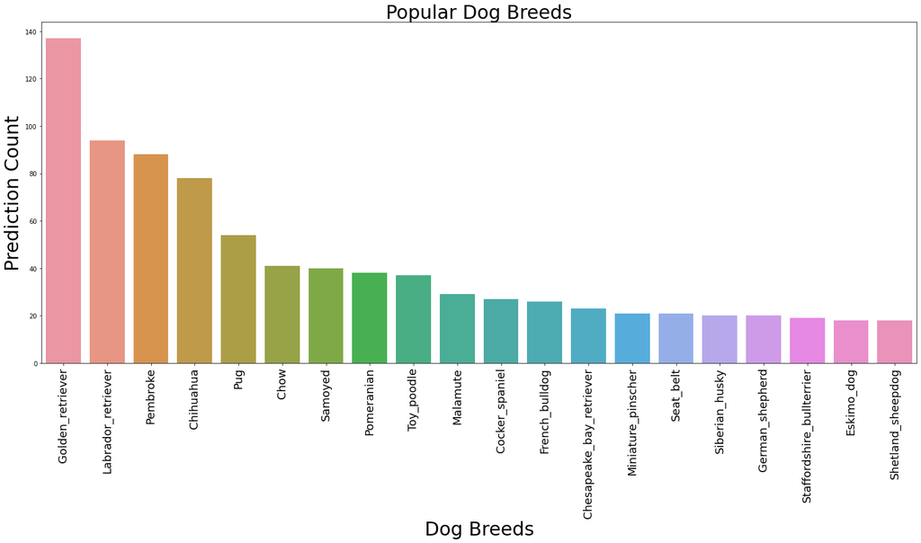

```python
#check the dog with highest breed
plt.figure(figsize = (25,10))
ax = snb.barplot(x = df_saved_merged['first_prediction'].value_counts()[0:20].index,
                y= df_saved_merged['first_prediction'].value_counts()[0:20],
                data = df_saved_merged);
ax.set_xticklabels(ax.get_xticklabels(), rotation = 90, fontsize = 18);
plt.xlabel('Dog Breeds', fontsize =30 );
plt.ylabel('Prediction Count', fontsize = 30);
plt.title('Popular Dog Breeds', fontsize = 30);
```

golden_retriever dog breeds has highest popularity due to its gentleness, affectionate in naure with fine colour and very accomodating. tThe golden_retriever have influence on users rating because of its good characteristic

# Lets check users count base on year

Pie chart is very useful in this case because it helps to show relationship of parts of the whole when there are small unmber of levels

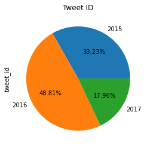

```python
#Check users count base on year..2016 has more tweet than 2015 & 2017
df_saved_merged.groupby('Year')['tweet_id'].count().plot(kind = 'pie', title = 'Tweet ID', autopct = '%.2f%%')
```

# 2016 has more tweet than 2015 & 2017

```python
#check the numeric values by year
df_saved_merged.groupby('Year')['tweet_id'].count().sort_values(ascending = True)
```

```
Year
2017    354
2015    655
2016    962
Name: tweet_id, dtype: int64
```

# Lets check ratings by month

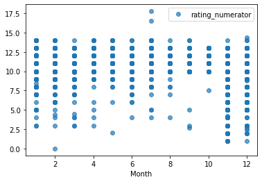

```python
#Rating using month
df_saved_merged.plot(y = 'rating_numerator', x = 'Month', style = 'o', alpha = .7)
```

# Lets check the dog phase with favourite count and bar chart is good

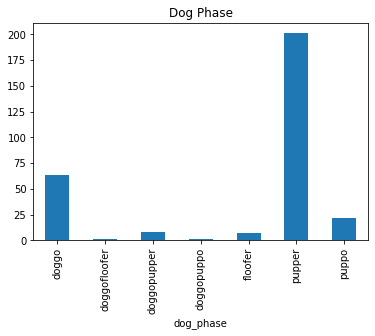

```python
df_saved_merged.groupby('dog_phase')['favorite_count'].count().plot(kind = 'bar', title = 'Dog Phase')
```

# Pupper is the youngest phase of dog and at the stage they looks beautiful and calm

#Lets check the users based on language

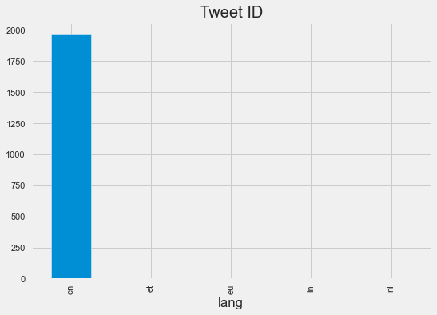

```python
#Check users count base on year..2016 has more tweet than 2015 & 2017
df_saved_merged.groupby('lang')['tweet_id'].count().plot(kind = 'bar', title = 'Tweet ID')
```

English users dominated which means the ratings might not be accepted by other users with another languages

# Conclussion

Well, due to course study project, data wrangling is the major focus here but however we can not ignore visualization & insight Judging from all the analysis that was done, it was deduced that pupper is the most popular phases in dog phase simply because they are younger and they looks cutter when young which influenced user ratings However golden_retriever dog breeds has highest popularity due to its gentleness, affectionate in naure with fine colour

In summary,It can be concluded that young,color, beauty & accomodating dogs is what influenced user in rating the dogs.

# Limitation

English speakers dominated the dog_rating dataset which limit the analysis to be widely accepted by other languages since they were not well represented. Scalling of numerator_ratings were normilized which somehow may not represent true users rating simply because it has been modified. #df = Av.AutoViz('df_master_table.csv', sep =',')